```python
%pylab inline
%matplotlib inline
```

[output not shown]

# Analyzing the NYC Subway Dataset

## References

Details on the Mann-Whitney U test, and Scipy's implementation: http://en.wikipedia.org/wiki/Mann%E2%80%93Whitney_U_test http://docs.scipy.org/doc/scipy-0.15.1/reference/generated/scipy.stats.mannwhitneyu.html

Some general help on Pandas functionality, including looking up methods I was not familiar with: http://pandas.pydata.org/pandas-docs/stable/generated/pandas.DataFrame.join.html http://pandas.pydata.org/pandas-docs/stable/generated/pandas.get_dummies.html http://pandas.pydata.org/pandas-docs/dev/generated/pandas.DatetimeIndex.html http://pandas.pydata.org/pandas-docs/stable/timeseries.html

Identifying when Memorial Day was in 2011. Also identifying Memorial Day as a public holiday: http://en.wikipedia.org/wiki/Public_holidays_in_the_United_States http://www.when-is.com/memorial-day-2011.asp

Some documentation on Statsmodels: http://statsmodels.sourceforge.net/devel/generated/statsmodels.regression.linear_model.RegressionResults.html http://statsmodels.sourceforge.net/devel/generated/statsmodels.regression.linear_model.RegressionResults.html?highlight=regressionresults

Some help on plotting in the iPython notebook (where is project is being drafted): http://stackoverflow.com/questions/19377371/how-to-make-a-histogram-in-ipython-notebook-using-ggplot2-for-python http://stackoverflow.com/questions/18379933/plotting-cumulative-counts-in-ggplot2

Discussion of the confounding variable effect arising from ommitting the day of week from the analysis: http://en.wikipedia.org/wiki/Confounding

## Section 1 - Statistical Test

Q1.1 Which statistical test did you use to analyze the NYC subway data? Did you use a one-tail or a two-tail P value? What is the null hypothesis? What is your p-critical value?

A1.1 In problem set 3, I used a 2-tailed Mann-Whitney U test. The null hypothesis is that the mean number of entries on rainy and non-rainy days are equal. The p-critical value used to determine statistical significance was 5%.

Q1.2 Why is this statistical test applicable to the dataset? In particular, consider the assumptions that the test is making about the distribution of ridership in the two samples.

A1.2 Subway ridership is not normally distributed. A nonparametric test like the Mann-Whitney U test is appropriate regardless of the distribution of the data samples. The Mann-Whitney U test does assume independence of observations.

Q1.3 What results did you get from this statistical test? These should include the following numerical values: p-values, as well as the means for each of the two samples under test.

A1.3 The means of the number of entries on rainy and non-rainy days were 1105.45 and 1090.28 respectively. A Mann–Whitney test (U = 1924409167, P <= 0.05 two-tailed) indicates that the means of the two distributions (number of entries with and without rain) are statistically different.

Q1.4 What is the significance and interpretation of these results?

A1.4 The test here shows that subway ridership is statistically significantly higher on rainy days compared to non-rainy days at the 5% level.

## Code for Section 1

```python
import numpy as np
import scipy
import scipy.stats as stats
import pandas as pd

turnstile_weather = pd.read_csv('turnstile_data_master_with_weather.csv')

def mann_whitney_plus_means(turnstile_weather):
    '''
    This function will consume the turnstile_weather dataframe containing
    our final turnstile weather data.

    You will want to take the means and run the Mann Whitney U-test on the
    ENTRIESn_hourly column in the turnstile_weather dataframe.

    This function should return:
        1) the mean of entries with rain
        2) the mean of entries without rain
        3) the Mann-Whitney U-statistic and p-value comparing the number of entries
           with rain and the number of entries without rain

    You should feel free to use scipy's Mann-Whitney implementation, and you
    might also find it useful to use numpy's mean function.

    Here are the functions' documentation:
    http://docs.scipy.org/doc/scipy/reference/generated/scipy.stats.mannwhitneyu.html
    http://docs.scipy.org/doc/numpy/reference/generated/numpy.mean.html

    You can look at the final turnstile weather data at the link below:
    https://www.dropbox.com/s/meyki2wl9xfa7yk/turnstile_data_master_with_weather.csv
    '''

    rain_entries = turnstile_weather[turnstile_weather['rain']==1]['ENTRIESn_hourly']
    no_rain_entries = turnstile_weather[turnstile_weather['rain']==0]['ENTRIESn_hourly']

    with_rain_mean = rain_entries.mean()
    without_rain_mean = no_rain_entries.mean()

    U,p = stats.mannwhitneyu(rain_entries, no_rain_entries)

    return with_rain_mean, without_rain_mean, U, p # leave this line for the grader

print mann_whitney_plus_means(turnstile_weather)
```

```
(1105.4463767458733, 1090.278780151855, 1924409167.0, 0.019309634413792565)
```

## Section 2 - Linear Regression

Q2.1 What approach did you use to compute the coefficients theta and produce prediction for ENTRIESn_hourly in your regression model?

A2.1 In the solution to problem set 3, I used the OLS capability of the statsmodels package to perform regression to predict ENTRIESn_hourly.

Q2.2 What features (input variables) did you use in your model? Did you use any dummy variables as part of your features?

A2.2 The features I used were:

- Whether it was raining that day ("rain")
- Whether the day for which the entries are to be predicted is a weekday or weekend (counting 30 May 2011, Memorial Day as a weekend). Weekdays are coded as 0 while non-work days are codes as 1. ("isHoliday")
- The amount of precipitation that day ("precipi")
- The mean temperature that day ("meantempi")

  I also used the following dummy features/categorical variables:
- The time of day for which we are predicting ENTRIESn_hourly ("Hour")
- The station for which the entries are to be predicted ("UNIT")

Note that since they are binary, the "rain" and "Weekday" features are essentially a categorical variables even though I did not treat them as such in my code. If I had called `pandas.get_dummies` on these features, I would have gotten 4 new indicator variables. Two of these would have been redundant.

Q2.3 Why did you select these features in your model? We are looking for specific reasons that lead you to believe that the selected features will contribute to the predictive power of your model. Your reasons might be based on intuition. For example, response for fog might be: “I decided to use fog because I thought that when it is very foggy outside people might decide to use the subway more often.” Your reasons might also be based on data exploration and experimentation, for example: “I used feature X because as soon as I included it in my model, it drastically improved my R2 value.”

A2.3 From intuition, I realised that the number of entries is a function of time of day (more riders in morning rush hour, for example), the subway station (busier stations have more riders) and the day of week (ridership patterns should change with whether it is a work day or not). I therefore ensured that these variables were accounted for in my model. For the question of day of week, I took care to split distinguish 2 types of days - work days (Mondays - Fridays) and non-work days (Saturdays, Sundays and Memorial Day, which is the last Monday of May). I only used 2 categories to distinguish days so as to reduce the number of variables in the model.

I added "rain" because the purpose of this project is to determine if rain has an impact on ridership, so I wanted to estimate its impact. I expected higher ridership on rainy days as commuters might choose to use the subway rather than walk in the rain. Similarly, "precipi" was added to the model as the amount of rain might influence commuters' decision to take the subway (ie. I would be more likely to take the subway if there was heavy rain than if it was a light drizzle).

Finally, I thought that temperature might be another reason for commuters to choose to take the subway as a commuter might prefer to ride rather than walk on a hot day.

Q2.4 What are the parameters (also known as "coefficients" or "weights") of the non-dummy features in your linear regression model?

A2.4 The coefficients can befound in the table below. Note that "rain" and "weekday" are essentially categorical variables even though they are treated as regular variables in this model.

| Variable | Coefficient | p-value |
| --- | --- | --- |
| rain | -11.0533 | 0.34 |
| precipi | 7.652303 | 0.55 |
| meantempi | 1.506406 | 0.035 |
| isHoliday | -594.359 | 0 |

Q2.5 What is your model’s R2 (coefficients of determination) value?

Q2.6 What does this R2 value mean for the goodness of fit for your regression model? Do you think this linear model to predict ridership is appropriate for this dataset, given this R2 value?

A2.6 This R^2 value indicates that about 50% of the variance in the data is explained by the model. This R^2 value is well above the ~40% R^2 target value for the problem set, so I believe it is a decently good fit.

I do not think a linear model is appropriate for this dataset, despite the reasonably good R^2 (on real world datasets that are not toy examples, I would expect R^2s in the 30-40% range). For example, changes in ridership should be a function of the base level of ridership at a station and for a time of day/week. In the linear model used here, an increase in the `precipi` variable can cause the ridership at a station which typically sees 50 entries/hour to increase to 60 entries/hour. I would **not** expect that a station which usually has 500 entries/hour to see a similar 10 entries/hour increase to 510 entries/hour. Instead, I would expect a proportional change to 600 entries/hour. In short, the linear model does not account for the scale of the base on which the effect is taking place. It assumes that changes in `ENTRIESn_hourly` due to each variable are indepdendent of other variables, which is counter-intuitive, as the impact on a busy station should be larger in the absolute number of entries per hour than for a station that is not heavily trafficked.

## Code for Section 2

```python
import numpy as np
import pandas
import pandas as pd
import statsmodels.api as sm

"""
In this question, you need to:
1) implement the linear_regression() procedure
2) Select features (in the predictions procedure) and make predictions.

"""
dataframe = pd.read_csv('turnstile_data_master_with_weather.csv')

def linear_regression(features, values):
    """
    Perform linear regression given a data set with an arbitrary number of features.

    This can be the same code as in the lesson #3 exercise.
    """

    X = sm.add_constant(features)
    y = values
    model = sm.OLS(y,X)
    results = model.fit()
    theta = results.params
    intercept = theta[0]
    params = theta[1:]
    pvals= results.pvalues
    return intercept, params,pvals

def predictions(dataframe):
    '''
    The NYC turnstile data is stored in a pandas dataframe called weather_turnstile.
    Using the information stored in the dataframe, let's predict the ridership of
    the NYC subway using linear regression with gradient descent.

    You can download the complete turnstile weather dataframe here:
    https://www.dropbox.com/s/meyki2wl9xfa7yk/turnstile_data_master_with_weather.csv

    Your prediction should have a R^2 value of 0.40 or better.
    You need to experiment using various input features contained in the dataframe.
    We recommend that you don't use the EXITSn_hourly feature as an input to the
    linear model because we cannot use it as a predictor: we cannot use exits
    counts as a way to predict entry counts.

    Note: Due to the memory and CPU limitation of our Amazon EC2 instance, we will
    give you a random subet (~10%) of the data contained in
    turnstile_data_master_with_weather.csv. You are encouraged to experiment with
    this exercise on your own computer, locally. If you do, you may want to complete Exercise
    8 using gradient descent, or limit your number of features to 10 or so, since ordinary
    least squares can be very slow for a large number of features.

    If you receive a "server has encountered an error" message, that means you are
    hitting the 30-second limit that's placed on running your program. Try using a
    smaller number of features.
    '''
    # Select Features (try different features!)
    features = dataframe[['rain', 'precipi','meantempi' ]]

    dates = pandas.DatetimeIndex(dataframe.DATEn)
    daytype = pandas.Series(data=dates.dayofweek,index=features.index)
    daytype = (daytype/5).astype(int) # seperate Monday-Friday(0-4) from Sat/Sun(5/6)
    daytype[dates.day==30] = 1 # treat Memorial Day as a weekend
    features.loc[:,'isHoliday'] = daytype
    hours = dataframe['Hour']
    dummy_units2 = pandas.get_dummies(hours,prefix='H')
    features = features.join(dummy_units2)

    # Add UNIT to features using dummy variables
    dummy_units = pandas.get_dummies(dataframe['UNIT'], prefix='unit')
    features = features.join(dummy_units)


    # Values
    values = dataframe['ENTRIESn_hourly']

    # Get the numpy arrays
    features_array = features.values
    values_array = values.values

    # Perform linear regression
    intercept, params,pvals = linear_regression(features_array, values_array)

    p = pd.Series(index=features.columns, data=params)
    p = p.to_frame()
    p['p'] = pvals[1:]
    p.columns  = ['theta','p-value']
    print p

    predictions = intercept + np.dot(features_array, params)
    return predictions

def compute_r_squared(data, predictions):
    '''
    In exercise 5, we calculated the R^2 value for you. But why don't you try and
    and calculate the R^2 value yourself.

    Given a list of original data points, and also a list of predicted data points,
    write a function that will compute and return the coefficient of determination (R^2)
    for this data.  numpy.mean() and numpy.sum() might both be useful here, but
    not necessary.

    Documentation about numpy.mean() and numpy.sum() below:
    http://docs.scipy.org/doc/numpy/reference/generated/numpy.mean.html
    http://docs.scipy.org/doc/numpy/reference/generated/numpy.sum.html
    '''

    SST = np.sum((data-np.mean(data))**2)
    SSReg = np.sum((data-predictions)**2)
    r_squared = 1-SSReg/SST

    return r_squared

q = predictions(dataframe)

y = dataframe.ENTRIESn_hourly

print compute_r_squared(y, q)
```

```
                 theta        p-value
rain        -11.053257   3.398672e-01
precipi       7.652303   5.504352e-01
meantempi     1.506406   3.477991e-02
isHoliday  -594.358987   0.000000e+00
H_0          39.867596   3.958027e-02
H_1        -338.651472   3.649433e-62
H_2        -207.785119   3.913068e-10
H_3        -104.843708   2.756679e-03
H_4        -862.238685   0.000000e+00
H_5        -793.561642   0.000000e+00
H_6        -373.700497   1.612977e-29
H_7        -464.081858   8.746460e-50
H_8        -625.218516  4.959343e-210
H_9         308.560350   2.731094e-53
H_10        -26.164805   4.234461e-01
H_11       -113.463036   8.532151e-04
H_12       1276.097331   0.000000e+00
H_13        145.301967   6.412881e-13
H_14       -333.154123   3.089368e-28
H_15       -106.068914   1.871739e-03
H_16        719.052863  1.987838e-301
H_17        583.215669  1.425960e-179
H_18        283.289480   2.416383e-17
H_19        170.578856   7.576730e-07
H_20       1512.647066   0.000000e+00
H_21        662.214833  1.902276e-228
H_22        141.005709   2.137155e-05
H_23        -53.741163   1.170119e-01
unit_R001  2606.625443  1.013958e-104
unit_R002  -461.409919   1.343676e-04
...                ...            ...
unit_R450  -851.686927   1.430510e-11
unit_R451  -439.416296   2.559899e-04
unit_R452  4377.966007  1.589312e-287
unit_R453   132.198579   3.072283e-01
unit_R454 -1568.602786   3.664966e-35
unit_R455 -1602.255854   4.838600e-37
unit_R456 -1398.434445   1.164713e-31
unit_R459 -1613.699473   1.957064e-19
```

[output cut: 10 more lines]

```
unit_R541 -1237.730681   0.000000e+00
unit_R542 -1260.085318  4.139570e-187
unit_R543 -1288.260114   0.000000e+00
unit_R544 -1297.461082  6.379849e-266
unit_R545 -1256.754003  1.203770e-226
unit_R546 -1112.362563  5.163189e-172
unit_R547 -1240.616852  9.979723e-102
unit_R548 -1182.419102   2.997402e-72
unit_R549 -1323.844055   0.000000e+00
unit_R550 -1292.186287   0.000000e+00
unit_R551 -1270.409061   0.000000e+00
unit_R552 -1182.425377   0.000000e+00

[493 rows x 2 columns]
0.514878587612
```

## Section 3 - Visualizations

### Visualization 1: Histograms

This visualization is taken from Problem Set 3. I tweaked the plot to match that in the Instructor Notes section.

```
<module 'matplotlib.pyplot' from 'C:\Anaconda\Lib\site-packages\matplotlib\pyplot.pyc'>
```

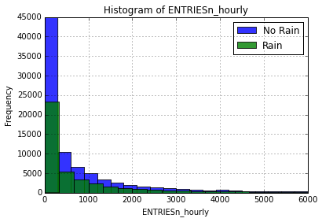

```python
import numpy as np
import pandas as pd
import matplotlib.pyplot as plt

def entries_histogram(turnstile_weather):
    '''
    Before we perform any analysis, it might be useful to take a
    look at the data we're hoping to analyze. More specifically, let's
    examine the hourly entries in our NYC subway data and determine what
    distribution the data follows. This data is stored in a dataframe
    called turnstile_weather under the ['ENTRIESn_hourly'] column.

    Let's plot two histograms on the same axes to show hourly
    entries when raining vs. when not raining. Here's an example on how
    to plot histograms with pandas and matplotlib:
    turnstile_weather['column_to_graph'].hist()

    Your histograph may look similar to bar graph in the instructor notes below.

    You can read a bit about using matplotlib and pandas to plot histograms here:
    http://pandas.pydata.org/pandas-docs/stable/visualization.html#histograms

    You can see the information contained within the turnstile weather data here:
    https://www.dropbox.com/s/meyki2wl9xfa7yk/turnstile_data_master_with_weather.csv
    '''

    plt.figure()
    plt.hold(True)
    q = turnstile_weather[turnstile_weather['ENTRIESn_hourly']<=6000]
    q[q['rain']==0]['ENTRIESn_hourly'].hist(bins=20, alpha=0.8)
    q[q['rain']==1]['ENTRIESn_hourly'].hist(bins=18, alpha=0.8)
    plt.legend(['No Rain','Rain'])
    plt.xlabel('ENTRIESn_hourly')
    plt.ylabel('Frequency')
    plt.title('Histogram of ENTRIESn_hourly')
    return plt


entries_histogram(turnstile_weather)
```

### Visualization 2: Cumulative Entries into Top N Stations

This visualization is taken from Problem Set 4. It shows how ridership is not uniformly distributed across subway stations. For eaxmple, the top 100 stations (of 465 total stations) account for more than 50% of ridership.

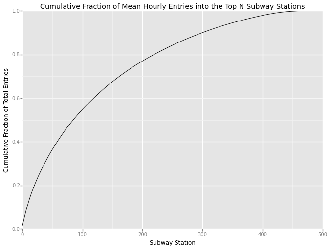

```
465
```

```python
from pandas import *
from ggplot import *

def plot_weather_data(turnstile_weather):
    '''
    plot_weather_data is passed a dataframe called turnstile_weather.
    Use turnstile_weather along with ggplot to make another data visualization
    focused on the MTA and weather data we used in Project 3.

    Make a type of visualization different than what you did in the previous exercise.
    Try to use the data in a different way (e.g., if you made a lineplot concerning
    ridership and time of day in exercise #1, maybe look at weather and try to make a
    histogram in this exercise). Or try to use multiple encodings in your graph if
    you didn't in the previous exercise.

    You should feel free to implement something that we discussed in class
    (e.g., scatterplots, line plots, or histograms) or attempt to implement
    something more advanced if you'd like.

    Here are some suggestions for things to investigate and illustrate:
     * Ridership by time-of-day or day-of-week
     * How ridership varies by subway station (UNIT)
     * Which stations have more exits or entries at different times of day
       (You can use UNIT as a proxy for subway station.)

    If you'd like to learn more about ggplot and its capabilities, take
    a look at the documentation at:
    https://pypi.python.org/pypi/ggplot/

    You can check out the link
    https://www.dropbox.com/s/meyki2wl9xfa7yk/turnstile_data_master_with_weather.csv
    to see all the columns and data points included in the turnstile_weather
    dataframe.

   However, due to the limitation of our Amazon EC2 server, we are giving you a random
    subset, about 1/3 of the actual data in the turnstile_weather dataframe.
    '''

    stationAves = turnstile_weather.groupby('UNIT').mean()['ENTRIESn_hourly']
    stationAves = stationAves.order(ascending=False).reset_index()['ENTRIESn_hourly']
    cumulativePctofEntries = stationAves.cumsum()/stationAves.sum()
    cumulativePctofEntries = cumulativePctofEntries.to_frame().reset_index()
    cumulativePctofEntries.columns = ['Subway Station','Cumulative Fraction of Total Entries']
    plot = ggplot(cumulativePctofEntries, aes(x='Subway Station',y='Cumulative Fraction of Total Entries') )
    plot += ggtitle('Cumulative Fraction of Mean Hourly Entries into the Top N Subway Stations')
    plot += geom_line()
    return plot


print plot_weather_data(turnstile_weather)


print len(np.unique(turnstile_weather['UNIT']))
```

## Section 4 - Conclusion

Q4.1 From your analysis and interpretation of the data, do more people ride the NYC subway when it is raining or when it is not raining?

A4.1 A simple statistical analysis, as in Section 1 above, and the first plot in Section 3 indicates that subway ridership is statistically significantly higher on days when it is raining. However, the analysis in Section 2 indicates that that there is no evidence of a significant change in ridership when it rains.

I believe that the analysis in Section 2 is more reliable, as it controls for confounding variables that are ommitted in the analysis of Section 1 and the naive charting in Section 3. I therefore conclude that this dataset provides is no statistical evidence that, all else being equal, subway ridership increases when it is raining.

Q4.2 What analyses lead you to this conclusion? You should use results from both your statistical tests and your linear regression to support your analysis.

### Code for Section 4

```python
import scipy.stats as stats
dat = turnstile_weather.copy()
dates = pd.DatetimeIndex(dat.DATEn)
daytype = pd.Series(data=dates.dayofweek,index=dat.index)
daytype = (daytype/5).astype(int) # Using casting like this should probably be discouraged
daytype[dates.day==30] = 1 # treat Memorial Day as a weekend
dat.loc[:,'isHoliday'] = daytype
holidays = dat.query('isHoliday==1')
notHolidays = dat.query('isHoliday==0')
print 'P(rain|isHoliday=1) = ' + str(holidays['rain'].mean())
print 'P(rain|isHoliday=0) = ' + str(notHolidays['rain'].mean())
print 'E(average entries per hour|isHoliday=1) = '+ str(holidays['ENTRIESn_hourly'].mean())
print 'E(average entries per hour|isHoliday=0) = '+ str(notHolidays['ENTRIESn_hourly'].mean())
# Is the probability of rain statistically significant on holidays vs. non-holidays? This is equivalent to checking if the means
# of holidays['rain'] and notHolidays['rain'] are the same, as these means are expectations of indicator variables
print stats.mannwhitneyu(holidays['rain'], notHolidays['rain'])
```

```
P(rain|isHoliday=1) = 0.29963898917
P(rain|isHoliday=0) = 0.351258167349
E(average entries per hour|isHoliday=1) = 687.202373014
E(average entries per hour|isHoliday=0) = 1295.99808958
(1824269271.5, 0.0)
```

## Section 5 - Reflection

5.1 Please discuss potential shortcomings of the methods of your analysis, including: Dataset; Analysis, such as the linear regression model or statistical test.

A5.1 I believe that the dataset is too small, leading to sampling bias in the analysis. The occurence of rain should be indepdendent of whether a day is a work day or a holiday. However, by only using 1 month worth of days, there is small sample bias, leading to a statistically significant increase in the probability of rain on a non-holiday, as can be seen in the Mann-Whitney U-test result in section 4 immediately above.

As mentioned in Section 2 earlier, the linear model fitted in this project may be inappropriate as well, since the linear model assumes that changes in factors lead to the same changes in `ENTRIESn_hourly` regardless of the time of day or station. Since some stations have much more traffic than others, as can be seen in plot 2 of Section 3 above, it is reasonable to assume that changes might be proportional to the average entries/hour for each station, rather than being independent of the station.

Finally, the statistical test in Section 1 was limited as it could not control for other effects (for example whether the day is a holiday or not) an thus lead to the erroneous conclusion that there ridership increases on rainy days.

Q5.2 (Optional) Do you have any other insight about the dataset that you would like to share with us?

A5.2 My main insight on the dataset is that its limited size introduces bias into the analysis. I would use data from the month of May (thus controlling for average temperatures, and removing the possibility of snowy days) over several years. By using several years of data, we may be able to add enough samples so that the probability of rain on non-holidays and holidays becomes roughly equal (ie: the expected indepdendence of rain and holidays is exhibited in the dataset). This would increase the size of the dataset, but we can limit the increase by limiting the analysis to just the top 50-100 stations (as seen in Section 3 above, the top 100 stations account for more than 50% of ridership).